# Bot Traffic Analysis

Wiktoria Kowalska

2026-01-29

### Używane biblioteki:

```r
library(dplyr)
library(mice)
library(psych)
library(ggplot2)
library(corrplot)
```

## Wstęp

Analizowany zestaw danych dotyczy aktywności użytkowników, udzielających się w komentarzach na Reddicie. Szczególny nacisk jest w nim pokładany na odpowiedzi wygenerowane przez boty. W poniższej analizie postaram się przybliżyć nasz zestaw jak i odpowiedzieć na pytania dotyczące algorytmu klasyfikującego komentarze.

Źródło danych: https://www.kaggle.com/datasets/nudratabbas/the-dead-internet-theory-reddit-bot-vs-human

Nasz zbiór zawiera kolumny:

- `comment_id` - unikalny identyfikator dla każdego komentarza
- `subreddit` - nazwa społeczności Reddita, do której możemy zaliczyć poszczególny komentarz
- `account_age_days` - wiek konta
- `user_karma` - punkty reprezentujące wiarygodność konta i jego wkład w społeczność Redditta
- `reply_delay_soconds` - liczba sekund od zamierszczenia posta do poszczególnej odpowiedzi
- `sentiment_score` - przedstawia emocjonalny wydźwięk danego komentarza
- `avg_word_length` - średnia ilość znaków na słowo
- `contains_links` - czy komentarz zawiera linki
- `is_bot_flag` - czy komentarz został oznaczony jako napisany przez bota
- `bot_type_label` - dzieli boty na poszczególne rodzaje
- `bot_probability` - prawdopodobieństwo, że odpowiedź została napisana przez bota

```r
bot_traffic <- read.csv("C:\\Users\\Wiktoria\\Desktop\\STUDIA\\rok 2\\semestr 1\\Analiza danych\\reddit_dead_internet_analysis_2026.csv", sep = ",")
```

## Czyszczenie danych

Zaczynam od usunięcia kolumny `comment_id`, poniważ zawiera identyfikatory komentarzy, które nic nie wnoszą do naszej analizy.

```r
bot_traffic <- bot_traffic %>%
  select(-comment_id)
```

Oglądam wartości w zbiorze

```r
head(bot_traffic, 3)
```

```
##   subreddit account_age_days user_karma reply_delay_seconds sentiment_score
## 1     funny             2264      34192                1854           -0.60
## 2    gaming             1654       2812                1033            0.15
## 3  politics             2442      37109                2703            0.35
##   avg_word_length contains_links is_bot_flag bot_type_label bot_probability
## 1            4.62          False       False   None (Human)           0.093
## 2            5.84          False       False   None (Human)           0.117
## 3            5.73          False       False   None (Human)           0.115
```

```r
tail(bot_traffic, 3)
```

```
##     subreddit account_age_days user_karma reply_delay_seconds sentiment_score
## 498      pics             2672      20283                1555            0.21
## 499      pics             2227       4322                1868           -0.38
## 500  politics             2246       4009                3197           -0.32
##     avg_word_length contains_links is_bot_flag bot_type_label bot_probability
## 498            4.85          False       False   None (Human)           0.097
## 499            5.48          False       False   None (Human)           0.110
## 500            5.42          False       False   None (Human)           0.109
```

Struktura danych:

```r
str(bot_traffic)
```

```
## 'data.frame':    500 obs. of  10 variables:
##  $ subreddit          : chr  "funny" "gaming" "politics" "funny" ...
##  $ account_age_days   : int  2264 1654 2442 168 801 1333 2582 380 2916 2797 ...
##  $ user_karma         : int  34192 2812 37109 32997 25088 17813 46483 6760 17095 43817 ...
##  $ reply_delay_seconds: int  1854 1033 2703 2811 1721 3237 1084 622 3486 2 ...
##  $ sentiment_score    : num  -0.6 0.15 0.35 -0.74 -0.96 0.93 0.98 -0.42 0.44 -0.15 ...
##  $ avg_word_length    : num  4.62 5.84 5.73 4.58 5.78 4.08 5.33 4.72 4.56 6.05 ...
##  $ contains_links     : chr  "False" "False" "False" "False" ...
##  $ is_bot_flag        : chr  "False" "False" "False" "False" ...
##  $ bot_type_label     : chr  "None (Human)" "None (Human)" "None (Human)" "None (Human)" ...
##  $ bot_probability    : num  0.093 0.117 0.115 0.094 0.116 0.082 0.107 0.096 0.091 0.254 ...
```

Zmieniam typ danych w kolumnach `contains_links` i `is_bot_flag` na zmienne kategoryczne ze zmianą nazw wartości:

```r
bot_traffic$is_bot_flag <- as.logical(bot_traffic$is_bot_flag)
bot_traffic$contains_links <- as.logical(bot_traffic$contains_links)
bot_traffic$is_bot_flag = factor(bot_traffic$is_bot_flag, levels = c(FALSE, TRUE),
                            labels = c("człowiek", "bot"))
bot_traffic$contains_links = factor(bot_traffic$contains_links, levels = c(FALSE, TRUE),
                     labels = c("nie_zawiera", "zawiera"))
```

Ustawiam również kolumny `bot_type_label` i `subreddit` jako factor bez określonej kolejności:

```r
bot_traffic$bot_type_label <- as.factor(bot_traffic$bot_type_label)
bot_traffic$subreddit <- as.factor(bot_traffic$subreddit)
```

Kolumna `sentiment_core` mówi o tonie poszczególnego kometarza (od negatywnego do pozytywnego), więc podzielę wyniki odzwierciedlające to i dodam na tej postawie nową kolumnę:

```r
bot_traffic$sentiment_category <- cut(bot_traffic$sentiment_score,
                                      breaks = c(-Inf, -0.1, 0.1, Inf),
                                      labels = c("Negatywny", "Neutralny", "Pozytywny"))
table(bot_traffic$sentiment_category)
```

```
##
## Negatywny Neutralny Pozytywny
##       221        54       225
```

Szukam braku danych i wartości odstających:

```r
summary(bot_traffic)
```

```
##       subreddit  account_age_days   user_karma    reply_delay_seconds
##  funny     :94   Min.   :   1     Min.   :  308   Min.   :   1
##  gaming    :92   1st Qu.: 163     1st Qu.:13427   1st Qu.:   7
##  pics      :81   Median :1092     Median :24779   Median : 459
##  politics  :83   Mean   :1158     Mean   :25248   Mean   :1031
##  technology:72   3rd Qu.:1960     3rd Qu.:37112   3rd Qu.:1925
##  worldnews :78   Max.   :2996     Max.   :49734   Max.   :3577
##  sentiment_score    avg_word_length     contains_links   is_bot_flag
##  Min.   :-1.00000   Min.   :4.030   nie_zawiera:386    człowiek:282
##  1st Qu.:-0.47250   1st Qu.:4.968   zawiera    :114    bot     :218
##  Median : 0.02000   Median :5.695
##  Mean   : 0.01498   Mean   :5.654
##  3rd Qu.: 0.50250   3rd Qu.:6.250
##  Max.   : 1.00000   Max.   :7.490
##            bot_type_label bot_probability  sentiment_category
##  AI Summarizer    : 66    Min.   :0.0810   Negatywny:221
##  Engagement Farmer: 86    1st Qu.:0.1010   Neutralny: 54
##  None (Human)     :282    Median :0.1170   Pozytywny:225
##  Reprint Bot      : 66    Mean   :0.1565
##                           3rd Qu.:0.2000
##                           Max.   :0.4650
```

```r
bot_traffic %>%
  select(account_age_days, user_karma, reply_delay_seconds, sentiment_score, avg_word_length, bot_probability) %>%
  describe()
```

```
##                     vars   n     mean       sd   median  trimmed      mad
## account_age_days       1 500  1157.62   951.77  1092.50  1099.53  1340.27
## user_karma             2 500 25248.20 14122.97 24778.50 25239.39 17745.24
## reply_delay_seconds    3 500  1030.70  1184.41   459.00   878.35   677.55
## sentiment_score        4 500     0.01     0.58     0.02     0.02     0.73
## avg_word_length        5 500     5.65     0.90     5.70     5.65     0.94
## bot_probability        6 500     0.16     0.07     0.12     0.14     0.05
##                        min      max    range  skew kurtosis     se
## account_age_days      1.00  2996.00  2995.00  0.30    -1.23  42.56
## user_karma          308.00 49734.00 49426.00  0.01    -1.18 631.60
## reply_delay_seconds   1.00  3577.00  3576.00  0.73    -0.94  52.97
## sentiment_score      -1.00     1.00     2.00 -0.01    -1.20   0.03
## avg_word_length       4.03     7.49     3.46  0.06    -0.83   0.04
## bot_probability       0.08     0.47     0.38  1.26     1.19   0.00
```

Nie mam braków, ale dla pewności sprawdzam jescze raz:

```
##  /\     /\
## {  `---'  }
## {  O   O  }
## ==>  V <==  No need for mice. This data set is completely observed.
##  \  \|/  /
##   `-----'
```

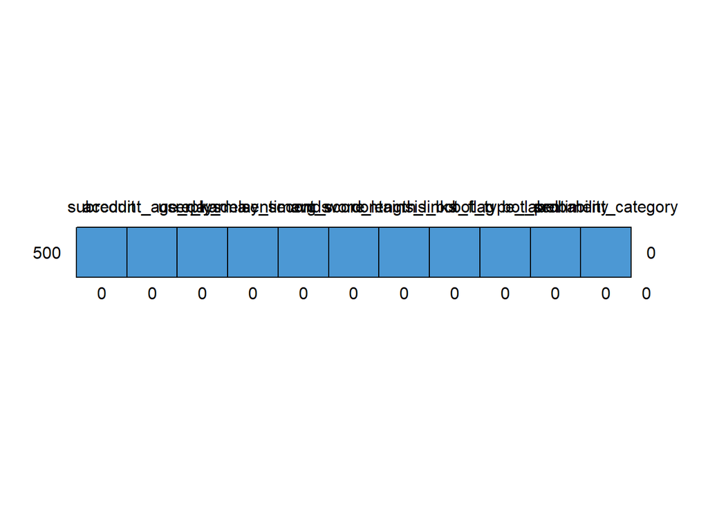

```
##     subreddit account_age_days user_karma reply_delay_seconds sentiment_score
## 500         1                1          1                   1               1
##             0                0          0                   0               0
##     avg_word_length contains_links is_bot_flag bot_type_label bot_probability
## 500               1              1           1              1               1
##                   0              0           0              0               0
##     sentiment_category
## 500                  1 0
##                      0 0
```

```r
md.pattern(bot_traffic)
```

Widzę też, że wystepują wartości odstające, ale na razie zostawiam je w spokoju.

## Rozkład zmiennych

Zaczynam od zmiennych kategorycznych:

- Zmienna `subreddit`

```r
table(bot_traffic$subreddit)
```

```
##
##      funny     gaming       pics   politics technology  worldnews
##         94         92         81         83         72         78
```

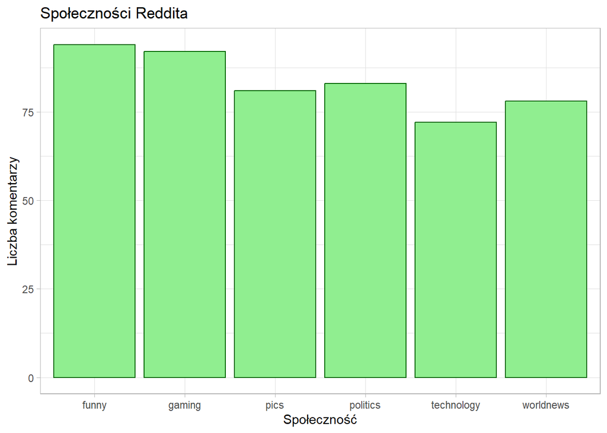

```r
bot_traffic %>%
  ggplot() +
  geom_bar(aes(x = subreddit), color = "darkgreen", fill = "lightgreen") +
  theme_light() +
  labs(title = "Społeczności Reddita",
       x = "Społeczność",
       y = "Liczba komentarzy")
```

Widać że dane są rozłożone dosyć równomiernie, brak wartości odstających.

- zmienna `bot_type_label`

```r
table(bot_traffic$bot_type_label)
```

```
##
##     AI Summarizer Engagement Farmer      None (Human)       Reprint Bot
##                66                86               282                66
```

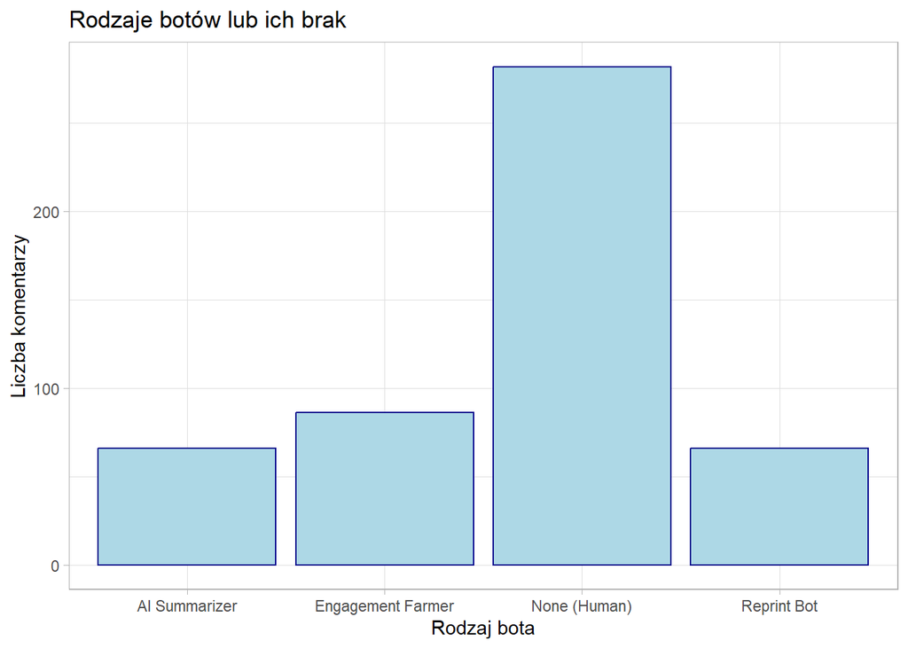

```r
bot_traffic %>%
  ggplot() +
  geom_bar(aes(x = bot_type_label), color = "darkblue", fill = "lightblue") +
  theme_light() +
  labs(title = "Rodzaje botów lub ich brak",
       x = "Rodzaj bota",
       y = "Liczba komentarzy")
```

Dominuje liczba komentarzy oznaczonych jak Human, jednak z 500 danych stanowi ona niewiele więcej niż 50%, to raczej mało.

- zmienna `sentiment_category`

```r
table(bot_traffic$sentiment_category)
```

```
##
## Negatywny Neutralny Pozytywny
##       221        54       225
```

Widać, że niewiele jest komentarzy neutralych, dominują skrajne odczucia.

- zmianna `contains_links`

```r
table(bot_traffic$contains_links)
```

```
##
## nie_zawiera     zawiera
##         386         114
```

Prawie 80% naszych danych nie zawiera linków.

- zmianna `is_bot_flag`

```r
table(bot_traffic$is_bot_flag)
```

```
##
## człowiek      bot
##      282      218
```

Zmienne ilościowe:

- zmienna `account_age_days`

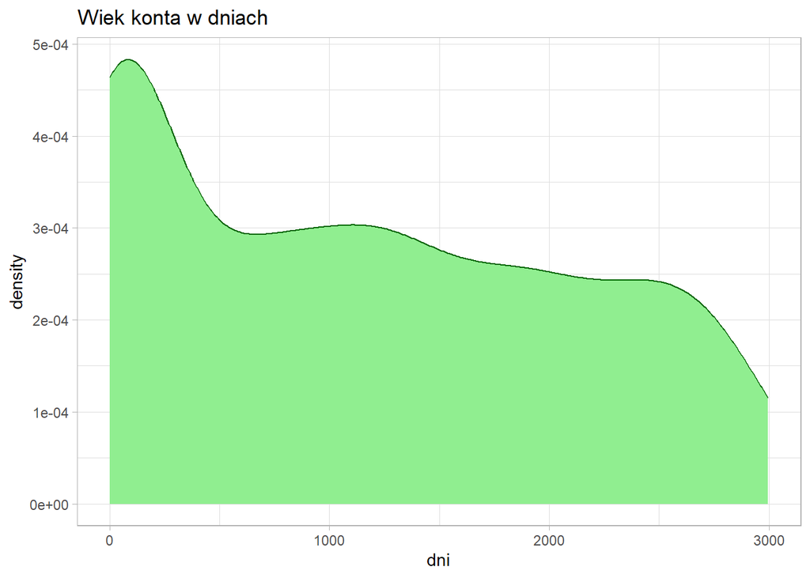

```r
bot_traffic %>%
  ggplot() +
  geom_density(aes(x = account_age_days),
               color = "darkgreen", fill = "lightgreen") +
  theme_light() +
  labs(title = "Wiek konta w dniach",
       x = "dni")
```

Rozkład wieku konta charakteruzuję się umiarkowaną skośnością prawostronną. Widać że największe zagęszczenie obserwujemy dla kont stosunkowo młodych (do 500 dni). Od tego momentu spadki są niewielkie aż do wartości 2500.

Spójrzmy na wykres pudełkowy w poszukiwaniu potencjalnych wartości odstających.

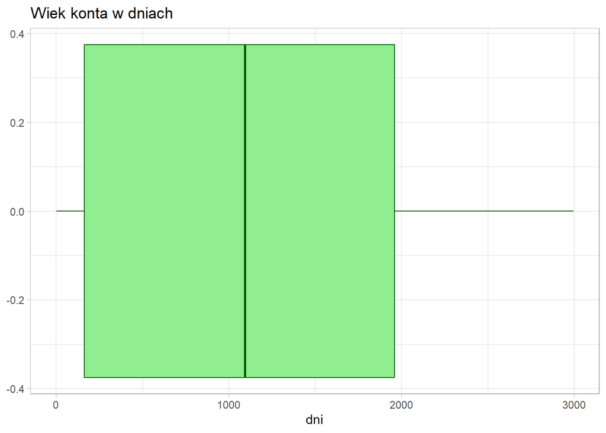

```r
bot_traffic %>%
  ggplot() +
  geom_boxplot(aes(x = account_age_days),
               color = "darkgreen", fill = "lightgreen") +
  theme_light() +
  labs(title = "Wiek konta w dniach",
       x = "dni")
```

Jak widzimy wartości odstających brak.

- zmienna `user_karma`

```r
describe(bot_traffic$user_karma)
```

```
##    vars   n    mean       sd  median  trimmed      mad min   max range skew
## X1    1 500 25248.2 14122.97 24778.5 25239.39 17745.24 308 49734 49426 0.01
##    kurtosis    se
## X1    -1.18 631.6
```

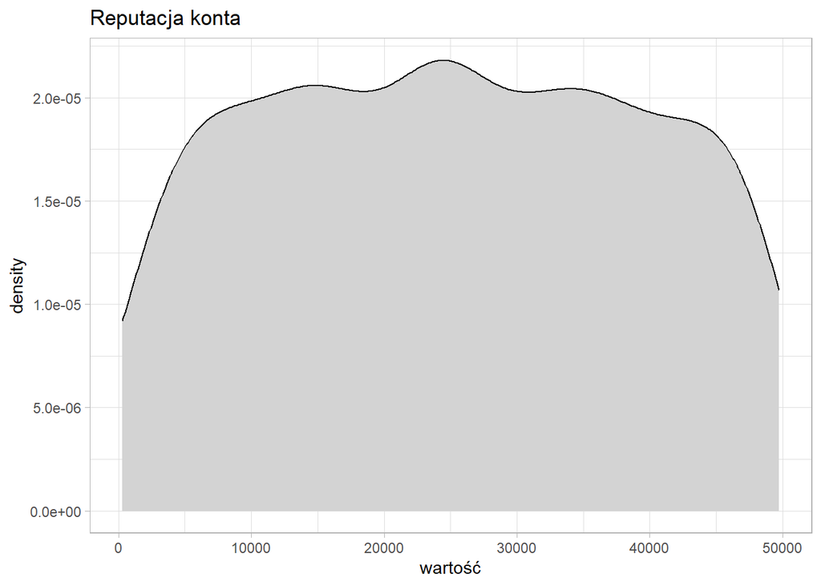

```r
bot_traffic %>%
  ggplot() +
  geom_density(aes(x = user_karma),
               color = "black", fill = "lightgrey") +
  theme_light() +
  labs(title = "Reputacja konta",
       x = "wartość")
```

Zmienna user_karma ma dosyć symetryczny rozkład, przy czym widzimy że zdecydowanie najmniej jest użytkowników z bardzo niską i bardzo wyską reputacją.

Narysujmy jeszcze wykres pudełkowy w poszukiwaniu wartości odstających.

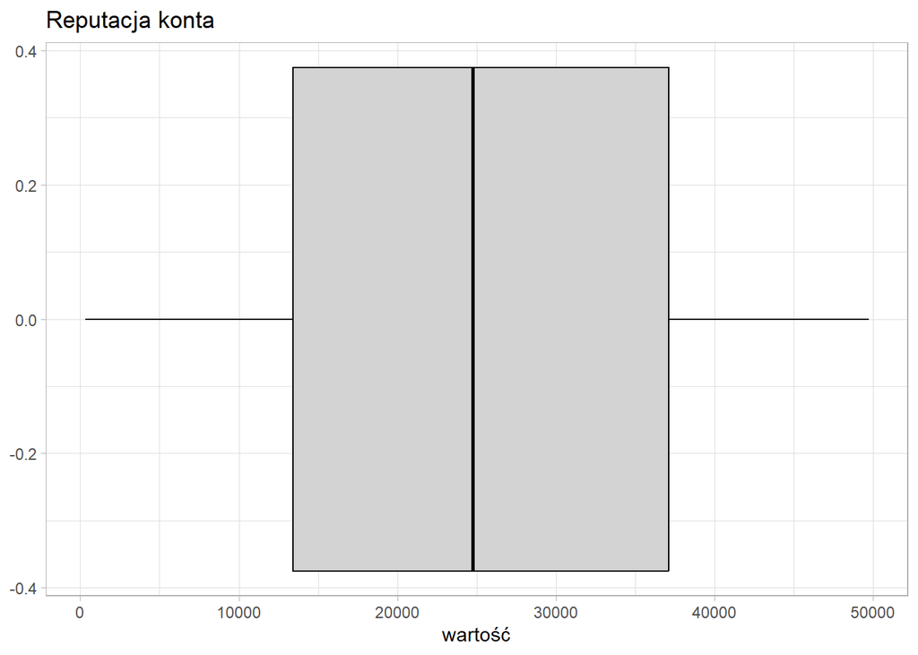

```r
bot_traffic %>%
  ggplot() +
  geom_boxplot(aes(x = user_karma),
               color = "black", fill = "lightgray") +
  theme_light() +
  labs(title = "Reputacja konta",
       x = "wartość")
```

Wartości odstających brak.

- zmienna `replay_delay_seconds`

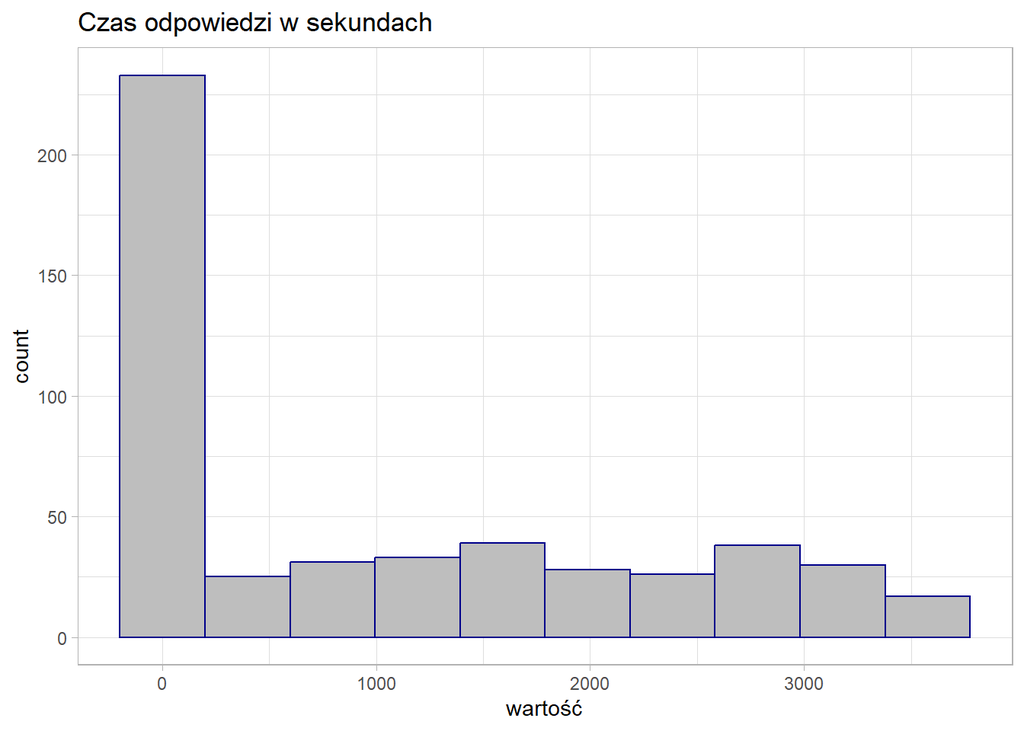

```r
bot_traffic %>%
  ggplot() +
  geom_histogram(aes(x = reply_delay_seconds),
                 bins = 10,
                 color = "darkblue", fill = "grey") +
  theme_light() +
  labs(title = "Czas odpowiedzi w sekundach",
       x = "wartość")
```

Zdecydowana część odpowiedzi to komentarze dodane do 10 minut po zamieszczeniu postu.

```r
summary(bot_traffic$reply_delay_seconds)
```

```
##    Min. 1st Qu.  Median    Mean 3rd Qu.    Max.
##       1       7     459    1031    1925    3577
```

- zmienna `avg_word_length`

```r
describe(bot_traffic$avg_word_length)
```

```
##    vars   n mean  sd median trimmed  mad  min  max range skew kurtosis   se
## X1    1 500 5.65 0.9    5.7    5.65 0.94 4.03 7.49  3.46 0.06    -0.83 0.04
```

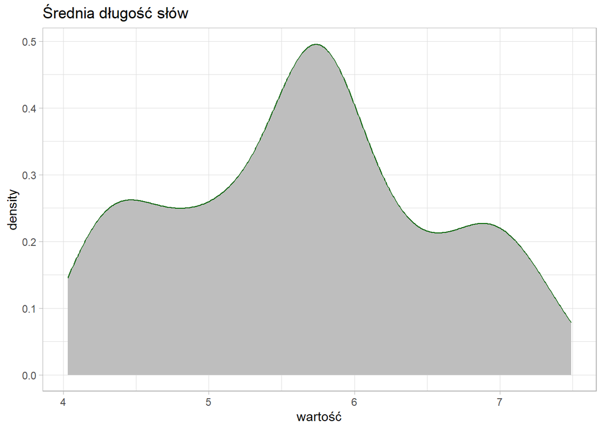

```r
bot_traffic %>%
  ggplot() +
  geom_density(aes(x = avg_word_length),
               color = "darkgreen", fill = "grey") +
  theme_light() +
  labs(title = "Średnia długość słów",
       x = "wartość")
```

Widzimy, że rozkład jest prawie symetryczny. Największe zagęszczenie mozna zaobserwować miedzy wartościami 5.5 i 6, choć nie sądzę, że ta zmienna jest znacząca dla naszej analizy.

- zmienna `bot_probability`

```r
summary(bot_traffic$bot_probability)
```

```
##    Min. 1st Qu.  Median    Mean 3rd Qu.    Max.
##  0.0810  0.1010  0.1170  0.1565  0.2000  0.4650
```

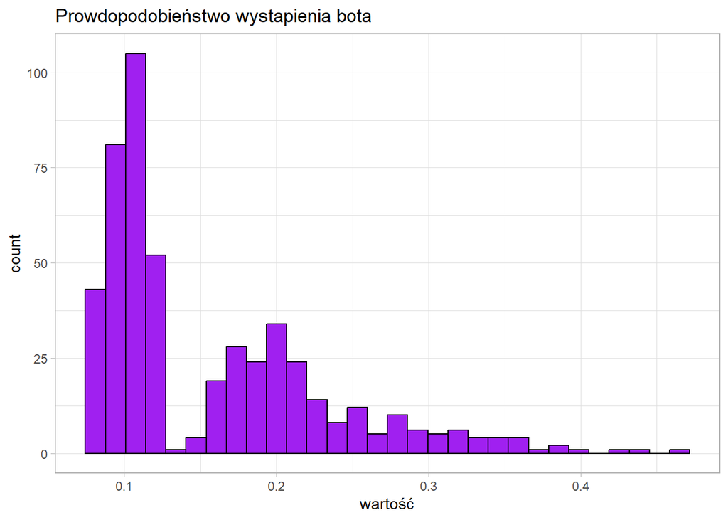

```r
bot_traffic %>%
  ggplot() +
  geom_histogram(aes(x = bot_probability),
               color = "black", fill = "purple") +
  theme_light() +
  labs(title = "Prowdopodobieństwo wystapienia bota",
       x = "wartość")
```

Wykres pokrywa się z informacjami ze zmiennej bot_type_label, ponieważ przeszło połowa komentarzy okazała się być napisana przez człowieka. Wartości powyżej 3.5 są naszymi outlinerami, które mogły zostać oznaczone jako boty, choć po raz kolejny odwołując się do wniosków z rozkładu zmiennej bot_type_label, 3.5 to nie jest wartość, od której stwierdzamy czy dany komentarz został napisany przez bota.

Wyznaczmy korelację między zmiennymi.

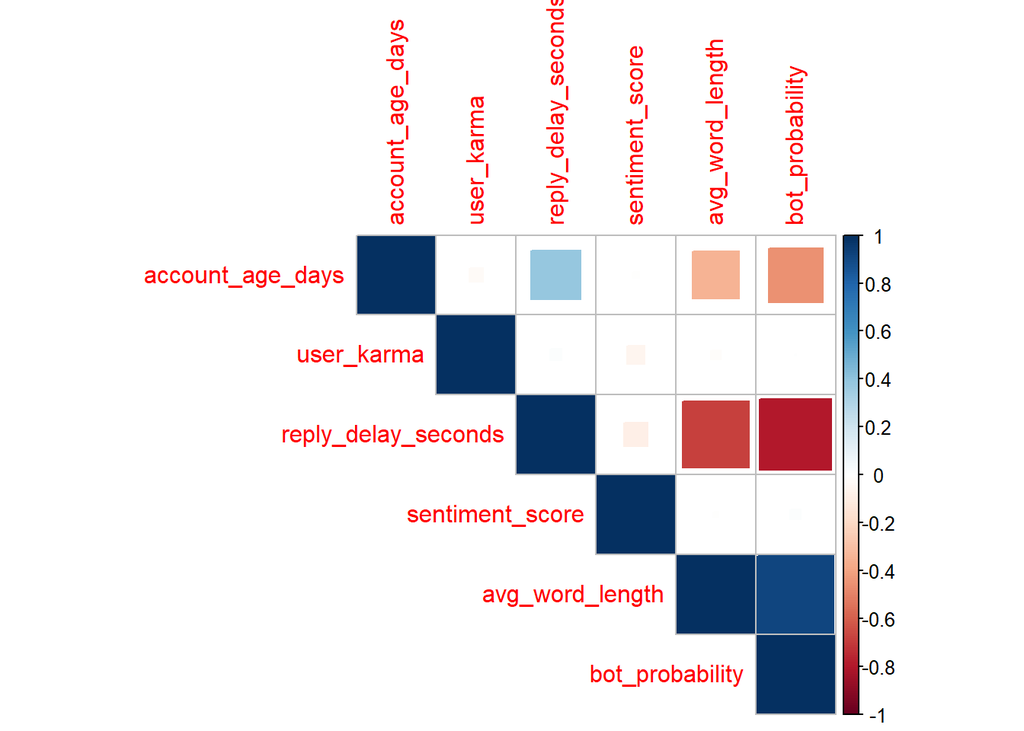

```r
cor = cor(bot_traffic[,c("account_age_days", "user_karma", "reply_delay_seconds",
                      "sentiment_score", "avg_word_length", "bot_probability")],
          method = "spearman")

corrplot(cor, method = "square", type = "upper")
```

Z powyższej macierzy korelcji możemy wywniskować, że:

Przeanalizujmy jeszcze zmienne kategoryczne względem siebie:

- `subreddit` a `bot_type_label`

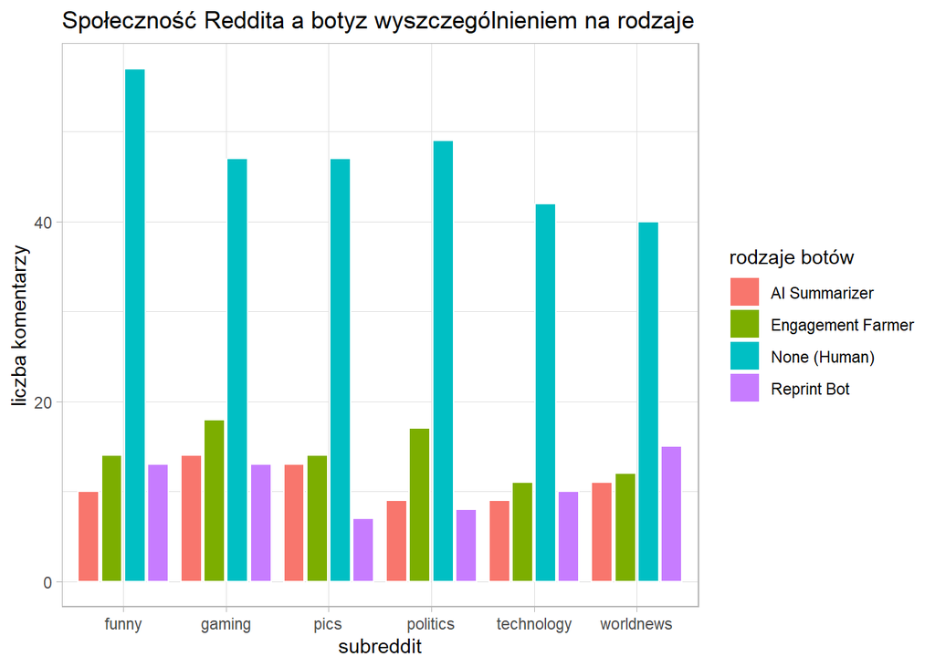

```r
bot_traffic %>%
  ggplot() +
  geom_bar(aes(x = subreddit, fill = bot_type_label),
           color = "white",
           position = "dodge2") +
  theme_light() +
  labs(title = "Społeczność Reddita a botyz wyszczególnieniem na rodzaje",
       x = "subreddit",
       y = "liczba komentarzy",
       fill = "rodzaje botów")
```

- `subreddit` a `is_bot_flag`

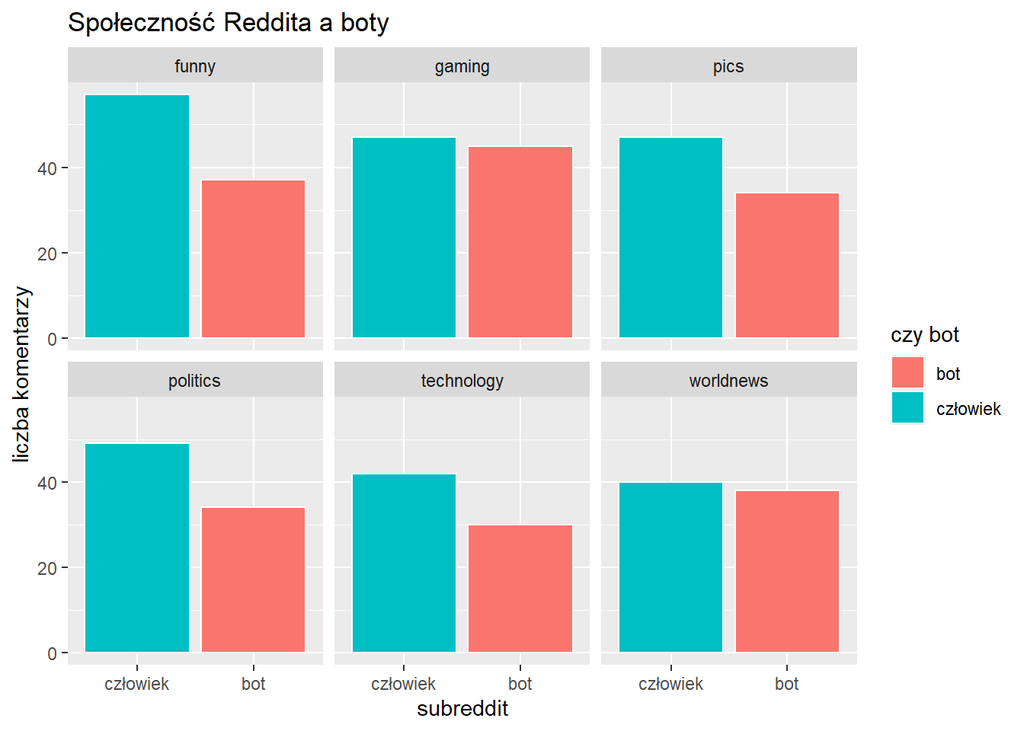

```r
bot_traffic %>%
  ggplot()+
  geom_bar(aes(x = is_bot_flag, fill = is_bot_flag),
           color = "white",
           position = "dodge2") +
  facet_wrap(~subreddit, ncol = 3) +
  scale_fill_discrete(limits = c("bot", "człowiek")) +
  labs(title = "Społeczność Reddita a boty",
       x = "subreddit",
       y = "liczba komentarzy",
       fill = "czy bot")
```

- `conatins_links` a `is_bot_flag`

```r
table(bot_traffic[,c("contains_links", "is_bot_flag")])
```

```
##               is_bot_flag
## contains_links człowiek bot
##    nie_zawiera      282 104
##    zawiera            0 114
```

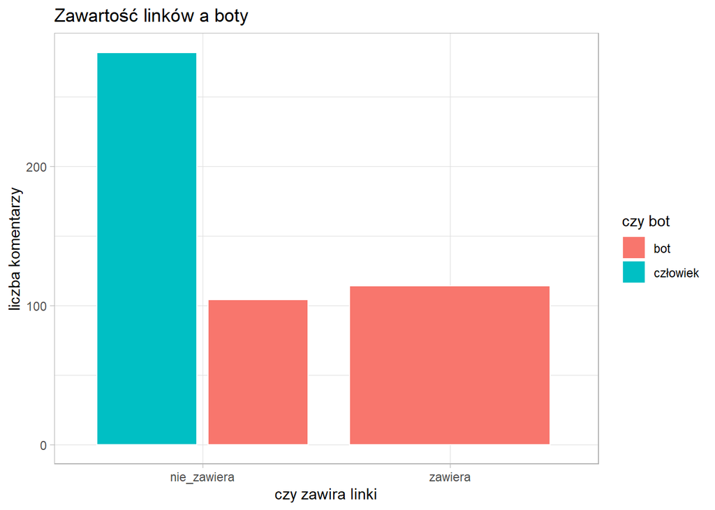

```r
bot_traffic %>%
  ggplot() +
  geom_bar(aes(x = contains_links, fill = is_bot_flag),
           color = "white",
           position = "dodge2") +
  scale_fill_discrete(limits = c("bot", "człowiek")) +
  theme_light() +
  labs(title = "Zawartość linków a boty",
       x = "czy zawira linki",
       y = "liczba komentarzy",
       fill = "czy bot")
```

- `is_bot_flag` a `sentiment_category`

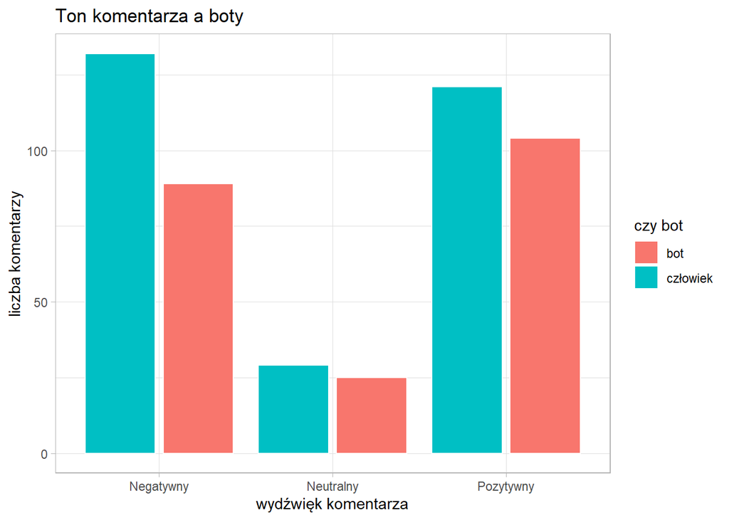

```r
bot_traffic %>%
  ggplot() +
  geom_bar(aes(x = sentiment_category, fill = is_bot_flag),
           color = "white",
           position = "dodge2") +
  theme_light() +
  scale_fill_discrete(limits = c("bot", "człowiek")) +
  labs(title = "Ton komentarza a boty",
       x = "wydźwięk komentarza",
       y = "liczba komentarzy",
       fill = "czy bot")
```

```r
table(bot_traffic[,c("is_bot_flag", "sentiment_category")])
```

```
##            sentiment_category
## is_bot_flag Negatywny Neutralny Pozytywny
##    człowiek       132        29       121
##    bot             89        25       104
```

## Pytania badawcze

Spróbujmy przyjrzeć się prawdopodobieństwu wystąpienia bota i zmiennym, które z tym korelują. Od jakiej wartości system stwierdza, że to bot? W jakim stopniu inne zmienne wpływają te liczby?

### Pytanie 1: Od której wartości komentarz oznaczany jest jako nie napisany przez człowieka?

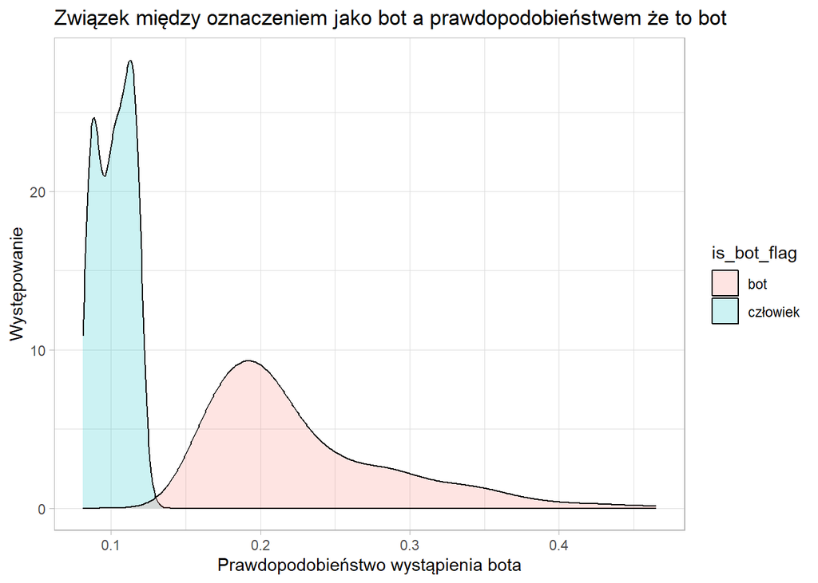

```r
bot_traffic %>%
  ggplot() +
  geom_density(aes(x = bot_probability, fill = is_bot_flag),
             color = "black", alpha = 0.2) +
  scale_fill_discrete(limits = c("bot", "człowiek")) +
  theme_light() +
  labs(title = "Związek między oznaczeniem jako bot a prawdopodobieństwem że to bot",
       x = "Prawdopodobieństwo wystąpienia bota",
       y = "Występowanie")
```

Spójrzmy jeszcze na statystyki opisowe.

```r
bot_traffic %>%
  group_by(is_bot_flag) %>%
  summarise(
    Min = min(bot_probability),
    Mediana = median(bot_probability),
    Max = max(bot_probability))
```

```
## # A tibble: 2 × 4
##   is_bot_flag   Min Mediana   Max
##   <fct>       <dbl>   <dbl> <dbl>
## 1 człowiek    0.081   0.103 0.128
## 2 bot         0.149   0.206 0.465
```

Widzimy, że nasza wartość dzięki której system będzie wiedział czy to bot znajduje się w przedziale 0.13 - 0.14. Możemy również dostrzec, że jest niewiele komentarzy, których jesteśmy połowicznie pewni, że są wygenerowane przez boty. Dużą gestością charkteryzyje się jedank wartość około 0.2. Czy możemy stwierdzić która zmienna na to wpływa?

### Pytanie 2: Jak prezentuję się zależność miedzy umieszczeniem linku w komentarzu a prawdopodbieństwem bota?

Widzieliśmy, że wszystkie komentarze z linkami są oznaczane jako boty. Sprwdźmy jak to się przekłada na prawdopodobieństwo.

```r
bot_traffic %>%
  group_by(contains_links) %>%
  summarise(
    Min = min(bot_probability),
    Mediana = median(bot_probability),
    Max = max(bot_probability))
```

```
## # A tibble: 2 × 4
##   contains_links   Min Mediana   Max
##   <fct>          <dbl>   <dbl> <dbl>
## 1 nie_zawiera    0.081   0.11  0.434
## 2 zawiera        0.151   0.204 0.465
```

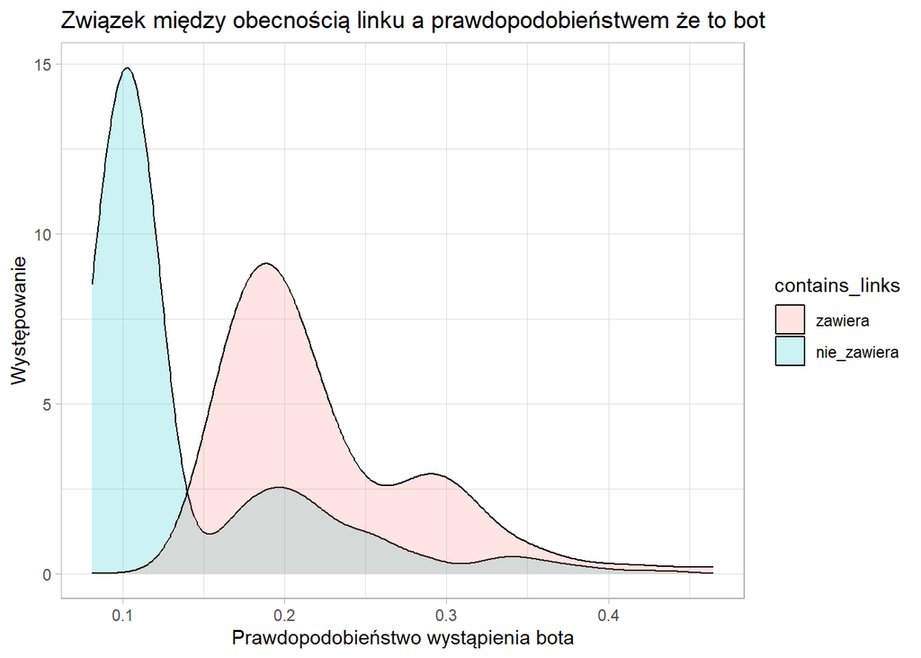

```r
bot_traffic %>%
  ggplot() +
  geom_density(aes(x = bot_probability, fill = contains_links),
               color = "black", alpha = 0.2) +
  scale_fill_discrete(limits = c("zawiera", "nie_zawiera")) +
  theme_light() +
  labs(title = "Związek między obecnością linku a prawdopodobieństwem że to bot",
       x = "Prawdopodobieństwo wystąpienia bota",
       y = "Występowanie")
```

### Pytanie 3: Jak wyglada zależność między średnią dłogością słów a prawdopodobieństwem wystapienia bota?

Wiemy, że zmienna `avg_word_length` koreluje prawie współliniowo z wartością określającą prawdopodobieństwo identyfikacji bota. Sprawdźmy czy możemy stwierdzić jakie średnie długości słów są charakterystyczne dla botów (według systemu Reddita).

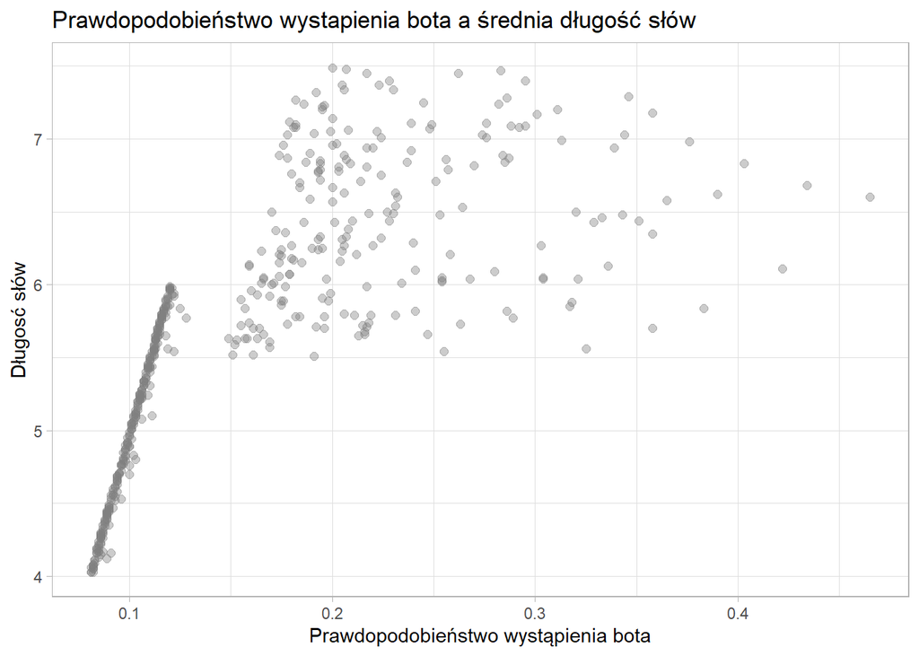

```r
bot_traffic %>%
  ggplot() +
  geom_point(aes(x = bot_probability, y = avg_word_length), size = 2,
             color = "grey50", alpha = 0.4) +
  theme_light() +
  labs(title = "Prawdopodobieństwo wystapienia bota a średnia długość słów",
       x = "Prawdopodobieństwo wystąpienia bota",
       y = "Długosć słów")
```

Widzimy, że kometarze oznaczone jako napisane przez człowieka tworzą prawie liniowy trend z niewielkimi odstępstwami - im większa średnia długość tym większe prawdopodobieństwo. Naszą szarą strefą są tutaj wartości 0d 5.5 do 6 - system jest tu niezdecydowany jak zidentifikować komentarz. Odcięcie jest tu, jednak wyraźne - komentarze o średniej długości słów większej niż 5.5 mają szansę być uznane za wygenerowane przez boty. Spójrzmy nastepnie na naszą szarą strfę (długość słów od 5.5 do 6). Jak inne zmienne pomagają w tym przypadku identyfikować boty?

### Pytanie 4: Jak zmianna reply_delay_seconds wpływa na parwdopodobieństwo wystąpienia bota?

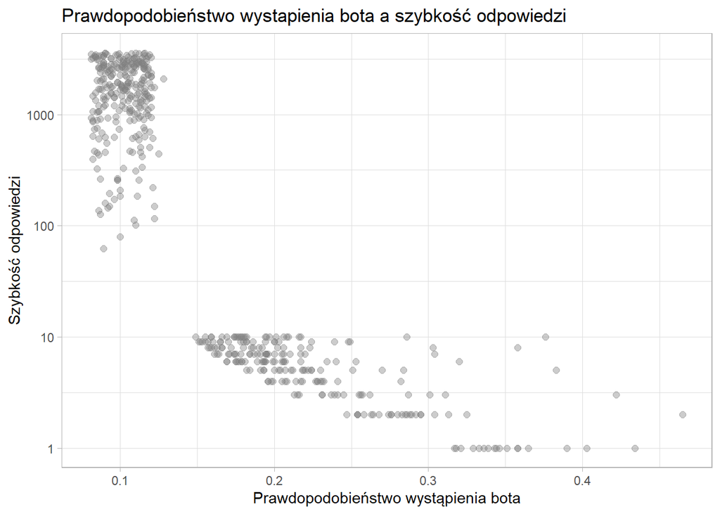

```r
bot_traffic %>%
  ggplot() +
  geom_point(aes(x = bot_probability, y = reply_delay_seconds), size = 2,
             color = "grey50", alpha = 0.4) +
  scale_y_log10() +
  theme_light() +
  labs(title = "Prawdopodobieństwo wystapienia bota a szybkość odpowiedzi",
       x = "Prawdopodobieństwo wystąpienia bota",
       y = "Szybkość odpowiedzi")
```

Widzimy, że odpowiedzi do 10 sekund są oznaczane jako generowane przez boty. Sprawdźmy, czy ta zmienna może być decydująca, w przypadku niepewności identifikacji.

### Pytanie 5: Czy możemy stwierdzić, że wartość zmiennej `reply_delay_seconds` roztrzyga kwestię wystąpienia bota (lub pomaga w tym), w przypadku gdy analiza średniej długości słów nie wystarcza?

```r
bot_traffic %>%
  filter(avg_word_length >= 5.5 & avg_word_length <= 6.0) %>%
  group_by(is_bot_flag) %>%
  summarise(
    Liczba_przypadkow = n(),
    Srednia_delay = mean(reply_delay_seconds),
    Mediana_delay = median(reply_delay_seconds),
    Min_delay = min(reply_delay_seconds),
    Max_delay = max(reply_delay_seconds)
  )
```

```
## # A tibble: 2 × 6
##   is_bot_flag Liczba_przypadkow Srednia_delay Mediana_delay Min_delay Max_delay
##   <fct>                   <int>         <dbl>         <int>     <int>     <int>
## 1 człowiek                   85       1776.            1601       116      3577
## 2 bot                        57          6.14             6         1        10
```

### Pytanie 6: Czy możemy stwierdzić, że wartość zmiennej `account_age_days` roztrzyga kwestię wystąpienia bota (lub pomaga w tym), w przypadku gdy analiza średniej długości słów nie wystarcza?

```r
bot_traffic %>%
  filter(avg_word_length >= 5.5 & avg_word_length <= 6.0) %>%
  group_by(is_bot_flag) %>%
  summarise(
    Liczba_przypadkow = n(),
    Srednia_days = mean(account_age_days),
    Mediana_days = median(account_age_days),
    Min_days = min(account_age_days),
    Max_days = max(account_age_days)
  )
```

```
## # A tibble: 2 × 6
##   is_bot_flag Liczba_przypadkow Srednia_days Mediana_days Min_days Max_days
##   <fct>                   <int>        <dbl>        <int>    <int>    <int>
## 1 człowiek                   85        1424.         1370       30     2996
## 2 bot                        57         896.          453        1     2945
```

Tutaj róznice już nie są aż tak znaczące. Nie obserwujemy aż tak dużej przepaści między średnimi, lecz wartości median są już bardziej zróżnicowane. Jeśli popatrzymy na wartości minimalne i maksymalne zarówno dla ludzi i botów, dostrzeżemy, że nakładają sie na siebie. Na podstawie tego możemy załozyć, że zmienna `account_age_days` jest zmienną pomocniczą, analiza średniej ilości słów zawodzi.

### Pytanie 7: Czym cechują się boty z najniższym prawdopodobieństwem identyfikującym ich jako boty?

Wyznaczmy statystyki

```r
ludzkie_boty <- bot_traffic %>%
  filter(is_bot_flag == "bot") %>%
  filter(bot_probability >= 0.11 & bot_probability <= 0.17) %>%
  select(subreddit, account_age_days, reply_delay_seconds, avg_word_length, contains_links, bot_type_label)
summary(ludzkie_boty)
```

```
##       subreddit account_age_days reply_delay_seconds avg_word_length
##  funny     :5   Min.   :  24.0   Min.   : 6.000      Min.   :5.520
##  gaming    :8   1st Qu.: 583.5   1st Qu.: 8.000      1st Qu.:5.630
##  pics      :3   Median :1272.0   Median : 9.000      Median :5.730
##  politics  :5   Mean   :1474.8   Mean   : 8.464      Mean   :5.826
##  technology:3   3rd Qu.:2500.5   3rd Qu.: 9.000      3rd Qu.:6.003
##  worldnews :4   Max.   :2945.0   Max.   :10.000      Max.   :6.500
##      contains_links           bot_type_label
##  nie_zawiera: 9     AI Summarizer    : 7
##  zawiera    :19     Engagement Farmer:11
##                     None (Human)     : 0
##                     Reprint Bot      :10
##
##
```

Podział ze względu na rodzaje botów i elementy kluczowe w rozpoznawaniu bota

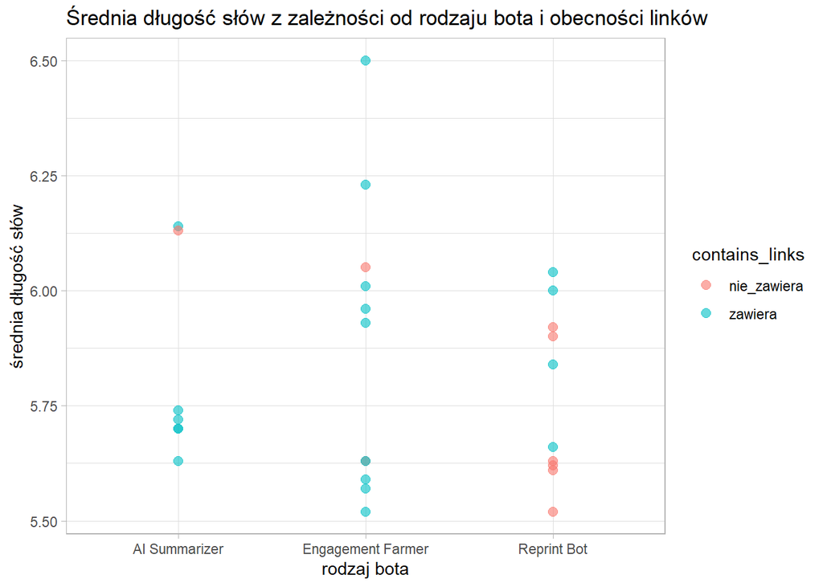

```r
ludzkie_boty %>%
  ggplot() +
  geom_point(aes(x = bot_type_label, y = avg_word_length, color = contains_links),
             size = 2.5, alpha = 0.6) +
  theme_light() +
  labs(title = "Średnia długość słów z zależności od rodzaju bota i obecności linków",
       x = "rodzaj bota",
       y = "średnia długość słów")
```

### Pytanie 8: Czym cechują się boty z najwyzszym prawdopodobieństwem identyfikującym ich jako boty?

Wyznaczmy statystyki

```r
napewno_boty <- bot_traffic %>%
  filter(is_bot_flag == "bot") %>%
  filter(bot_probability >= 0.35) %>%
  select(subreddit, account_age_days, reply_delay_seconds, avg_word_length, contains_links, bot_type_label)
summary(napewno_boty)
```

```
##       subreddit account_age_days reply_delay_seconds avg_word_length
##  funny     :2   Min.   : 1.000   Min.   : 1.000      Min.   :5.700
##  gaming    :3   1st Qu.: 1.000   1st Qu.: 1.000      1st Qu.:6.290
##  pics      :0   Median : 4.000   Median : 1.000      Median :6.590
##  politics  :4   Mean   : 7.167   Mean   : 2.917      Mean   :6.492
##  technology:1   3rd Qu.:11.250   3rd Qu.: 3.500      3rd Qu.:6.718
##  worldnews :2   Max.   :27.000   Max.   :10.000      Max.   :7.180
##      contains_links           bot_type_label
##  nie_zawiera:7      AI Summarizer    :4
##  zawiera    :5      Engagement Farmer:3
##                     None (Human)     :0
##                     Reprint Bot      :5
##
##
```

Widzimy, że średnia długość słów przekracza 5.5 a czas odpowiedzi to maksymalnie 10 sekund. Obie te zmienne pozwalają zakwalifikować dany komentarz jako bot z przeszło 35 procentowym prawdopodobieństwem.